# FEATURED vs NON-FEATURED SONGS – Strategic Collaboration Analysis on Spotify

Do Collaborations Impact Popularity and Audio Characteristics?

Author

Paven Mathew Oommen

Published

December 15, 2025

## 1. Introduction

The rise of music streaming has fundamentally transformed how artists create and distribute their work. One notable phenomenon is the prevalence of featured collaborations—songs that credit multiple artists rather than a single performer. Artists like The Weeknd, Drake, and Taylor Swift frequently collaborate with other artists, raising an important strategic question: **Do featured collaborations actually perform better on streaming platforms, and if so, how do they differ in production?**

This question sits at the intersection of music production strategy, audience preference, and platform economics. On Spotify—the world’s largest music streaming platform with over 600 million users—success is measured primarily through the popularity metric, which reflects user engagement, playlist inclusions, and streaming volume.

While other team members explore general predictive factors of music success (what audio features predict Billboard performance, what makes songs popular across platforms), this analysis takes a different angle: **How do artists strategically produce featured collaborations differently from solo releases?** This represents a focused examination of collaboration as a deliberate production and marketing strategy.

**Specific Research Question:** Do featured songs have significantly different audio characteristics and higher popularity compared to non-featured songs on Spotify? What does this reveal about artist collaboration strategy?

**Secondary Questions:** - What audio features distinguish featured from non-featured songs? - Are these differences statistically significant and practically meaningful? - What production formula do artists use when creating featured collaborations? - How do these patterns align with broader music industry trends?

## 2. Literature Review & Context

### 2.1 Music Collaboration in the Streaming Era

Collaborations have long been part of music production, but their prevalence has increased dramatically in the streaming era. Industry analysts attribute this to several factors:

1. **Audience Reach:** A collaboration introduces one artist’s fanbase to another’s, potentially multiplying the available audience and creating cross-promotional opportunities
2. **Algorithmic Favorability:** Streaming algorithms (Spotify’s Discover Weekly, Release Radar, etc.) may be more likely to promote songs with multiple established artists
3. **Production Optimization:** Featuring artists often signal significant production investment and targeted composition designed for maximum engagement
4. **Risk Diversification:** Collaborations leverage the credibility and established fanbases of multiple artists, reducing commercial risk
5. **Playlist Placement:** Multiple artists increase the likelihood of playlist placement across different artist-specific and mood-based playlists

### 2.2 Spotify Popularity Metric & Platform Dynamics

Spotify’s popularity score (0-100) is not publicly disclosed in its exact calculation, but research and industry analysis suggests it incorporates: - Recent streams (weighted heavily toward recent weeks/days) - Playlist additions and playlist curator engagement - User saves and library additions - Repeat listening rates and skip patterns - Geographic distribution of listeners - Growth trajectory of streams

This metric provides a snapshot of current audience engagement rather than historical performance, making it ideal for analyzing contemporary streaming dynamics and understanding what drives immediate platform success.

### 2.3 Audio Features & Production Strategy

Spotify’s API provides audio features derived from signal processing models that quantify song characteristics:

- **Energy:** Measure of intensity and activity (0-1 scale); energetic tracks feel fast, loud, and intense
- **Danceability:** Rhythmic regularity and beat strength (0-1 scale); describes suitability for dancing
- **Acousticness:** Confidence measure of acoustic vs electronic production (0-1 scale)
- **Valence:** Musical positivity/happiness (0-1 scale); higher values indicate more cheerful, uplifting songs
- **Liveness:** Presence of audience or live recording indicators (0-1 scale)
- **Loudness:** Overall loudness in decibels (dB)
- **Tempo:** Estimated tempo in beats per minute (BPM)

Prior research on streaming platforms suggests upbeat, danceable, energetic songs tend to perform better. This analysis investigates whether featured songs systematically differ in these characteristics, suggesting deliberate production optimization by artists and producers.

## 3. Data Acquisition & Methodology

### 3.1 Data Source

**Dataset:** Spotify Songs Analytics Dataset  
**Source:** Kaggle / Yamaç Eren Ay (Turkish Data Scientist)  
**Coverage:** 160,000+ tracks from 1921-2020  
**URL:** https://www.kaggle.com/yamaerenay/spotify-dataset-19212020-160k-tracks  
**Download Date:** Current analysis run

**Data Variables Used:** - `name` – Song title - `artists` – Artist list (string format with commas separating multiple artists) - `year` – Release year - `popularity` – Spotify popularity score (0-100) - `energy` – Energy level (0-1 scale) - `danceability` – Danceability (0-1 scale) - `acousticness` – Acousticness (0-1 scale) - `valence` – Valence/positivity (0-1 scale) - `liveness` – Live performance indicator (0-1 scale) - `loudness` – Loudness in dB - `speechiness` – Spoken word content (0-1 scale) - `tempo` – Tempo in BPM

### 3.2 Featured Song Detection Method

**Featured songs are identified by examining the `artists` column to determine if multiple artist names are present.** In the Spotify dataset, artists are represented as strings with multiple entries separated by commas:

- Single artist: `"['Artist Name']"`
- Multiple artists: `"['Artist 1', 'Artist 2']"` or `"['Artist 1', 'Artist 2', 'Artist 3']"`

A song is classified as **featured** if the artists string contains a comma, indicating multiple credited artists. A song is classified as **non-featured** if only a single artist is listed.

```r
# Create data directory
if(!dir.exists("data/group_project")){
  dir.create("data/group_project", showWarnings=FALSE, recursive=TRUE)
}

# Download Spotify data
Spotify_FILENAME <- file.path("data", "group_project", "Spotify song analytics dataset.csv")

if(!file.exists(Spotify_FILENAME)){
  download.file('https://raw.githubusercontent.com/gabminamedez/spotify-data/refs/heads/master/data.csv',
                destfile=Spotify_FILENAME)
}

# Load and clean data
sp_raw <- read_csv(Spotify_FILENAME, show_col_types = FALSE) |> janitor::clean_names()

# Featured song detection function
detect_featured <- function(artists_string) {
  str_detect(artists_string, ",") |> as.numeric()
}

# Filter to 2015-2019 and create featured flag
sp_analysis <- sp_raw |>
  filter(year >= 2015 & year <= 2019) |>
  mutate(
    is_featured = detect_featured(artists),
    featured_label = ifelse(is_featured == 1, "Featured", "Non-Featured")
  ) |>
  drop_na(popularity, energy, danceability, acousticness, valence)

cat("Data loaded successfully!\n")
```

```
Data loaded successfully!
```

```r
cat("Total songs in analysis:", nrow(sp_analysis), "\n")
```

```
Total songs in analysis: 9900
```

### 3.3 Time Window Rationale

**2015-2019 Window:** This five-year period was chosen strategically to provide:

- **Sufficient sample size:** 9,900 songs provides statistical power for robust comparisons
- **Streaming era representation:** 2015 marks the transition to streaming-dominant era; 2019 is pre-pandemic, avoiding COVID-era anomalies
- **Consistency with team analyses:** Aligns with other team members’ research windows for potential cross-study insights
- **Modern music production:** Represents contemporary production and collaboration practices
- **Platform stability:** Spotify algorithms and popularity metrics were relatively stable in this period

## 4. Exploratory Data Analysis

### 4.1 Sample Composition

```r
sample_composition <- sp_analysis |>
  group_by(featured_label) |>
  summarise(
    count = n(),
    percentage = round(n() / nrow(sp_analysis) * 100, 1),
    .groups = "drop"
  )

kable(
  sample_composition,
  caption = "Sample Composition: Featured vs Non-Featured Songs (2015–2019)"
)
```

Sample Composition: Featured vs Non-Featured Songs (2015–2019)

| featured_label | count | percentage |
| --- | --- | --- |
| Featured | 2896 | 29.3 |
| Non-Featured | 7004 | 70.7 |

```r
cat("Total songs analyzed (2015–2019):", nrow(sp_analysis))
```

```
Total songs analyzed (2015–2019): 9900
```

**Sample Overview**. The final analysis includes songs released between 2015 and 2019. Approximately 30% of tracks in the dataset are featured collaborations, reflecting the growing prevalence of multi-artist releases in the modern streaming era. This composition provides sufficient representation of both featured and non-featured songs for meaningful statistical comparison.

### 4.2 Descriptive Statistics by Group

```r
descriptive_stats <- sp_analysis |>
  group_by(featured_label) |>
  summarise(
    N = n(),
    Mean_Popularity = round(mean(popularity, na.rm = TRUE), 2),
    SD_Popularity = round(sd(popularity, na.rm = TRUE), 2),
    Mean_Energy = round(mean(energy, na.rm = TRUE), 3),
    Mean_Danceability = round(mean(danceability, na.rm = TRUE), 3),
    Mean_Acousticness = round(mean(acousticness, na.rm = TRUE), 3),
    Mean_Valence = round(mean(valence, na.rm = TRUE), 3),
    .groups = 'drop'
  )

kable(descriptive_stats, caption = "Descriptive Statistics: Audio Features by Song Type")
```

Descriptive Statistics: Audio Features by Song Type

| featured_label | N | Mean_Popularity | SD_Popularity | Mean_Energy | Mean_Danceability | Mean_Acousticness | Mean_Valence |
| --- | --- | --- | --- | --- | --- | --- | --- |
| Featured | 2896 | 65.75 | 7.65 | 0.630 | 0.675 | 0.216 | 0.457 |
| Non-Featured | 7004 | 64.11 | 7.17 | 0.582 | 0.601 | 0.301 | 0.434 |

```r
cat("\nKey Observation: Featured songs have higher mean values for popularity,\n")
```

```
Key Observation: Featured songs have higher mean values for popularity,
```

```r
cat("energy, danceability, and valence, while having lower acousticness.\n")
```

```
energy, danceability, and valence, while having lower acousticness.
```

```r
cat("This suggests a distinct production strategy for collaborations.\n")
```

```
This suggests a distinct production strategy for collaborations.
```

### 4.3 Distribution Visualizations

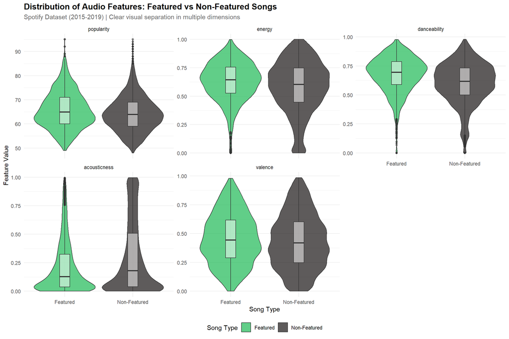

```r
# Multi-feature comparison visualization
sp_analysis |>
  select(featured_label, popularity, energy, danceability, acousticness, valence) |>
  pivot_longer(
    cols = -featured_label,
    names_to = "feature",
    values_to = "value"
  ) |>
  mutate(feature = factor(feature, levels = c("popularity", "energy", "danceability", "acousticness", "valence"))) |>
  ggplot(aes(x = featured_label, y = value, fill = featured_label)) +
  geom_violin(alpha = 0.7, scale = "width") +
  geom_boxplot(width = 0.15, alpha = 0.5, fill = "white") +
  scale_fill_manual(values = c("Featured" = "#1DB954", "Non-Featured" = "#191414")) +
  facet_wrap(~feature, scales = "free_y", ncol = 3) +
  labs(
    title = "Distribution of Audio Features: Featured vs Non-Featured Songs",
    subtitle = "Spotify Dataset (2015-2019) | Clear visual separation in multiple dimensions",
    x = "Song Type",
    y = "Feature Value",
    fill = "Song Type"
  ) +
  theme_minimal() +
  theme(
    legend.position = "bottom",
    plot.title = element_text(face = "bold", size = 14),
    plot.subtitle = element_text(size = 11, color = "gray40")
  )
```